# Combine species taxonomy, phylogeny, body mass, function groups, and machine-learning predicted sensitivity

This notebook will combine predicted species sensitivity with species information (taxonomy, phylogeny, body mass, and functional groups) for further analysis. This notebook will also read chemical group information collected from PPDB database and filter the combined dataset to selected chemicals with known pesticide types. Hence, combined dataset and sub dataset for selected chemicals will be saved in the end.

```r
rm(list=ls())
library(here)
library(tidyverse)
library(knitr)
library(kableExtra)
library(tidyverse)
library(data.table)

options(dplyr.summarise.inform = FALSE)
```

# 1. Read species dataset

Read species’s dataset

```r
spe_tax_phylo_BM_FFG <- readRDS(here("data/6_combined/spe_tax_phylo_BM_FFG.rds")) %>%
    mutate(log_mass = log10(mean_mass_g))
```

Calculate centered species’ body masses:

```r
spe_tax_phylo_BM_FFG  <- spe_tax_phylo_BM_FFG %>% mutate(log_mass_c = scale(log_mass, center = TRUE, scale = FALSE)[,1])
```

# 2. Filter predicted sensitivity dataset

```r
# Load the prediction dataset
#predicted_sensitivity <- read_csv(here("data/2_predicted_sensitivity/predictions.csv"))
#predicitons_ML_duration24h <- predicted_sensitivity %>% filter(duration ==24)
predicitons_ML_duration24h <- readRDS(here("data/2_predicted_sensitivity/predicitons_ML_duration24h.rds"))

# correct species names
predicted_sensitivity <- predicitons_ML_duration24h %>%
  mutate(latin = species) %>%
  mutate(
    latin = case_when(
      latin == "lithodes antarcticus" ~ "lithodes antarctica",
      latin == "Viviparus bengalensis" ~ "filopaludina bengalensis",
      latin == "acanthomysis sculpta" ~ "holmesimysis sculpta",
      latin == "acartia clausi" ~ "acartia clausii",
      latin == "acartia lillgeborgi" ~ "acartia lilljeborgii",
      latin == "acheilognathus moriokae" ~ "acheilognathus melanogaster",
      latin == "achnanthes minutissima" ~ "achnanthidium minutissimum",
      latin == "nuria danrica" ~ "esomus danrica",
      latin == "oreochromis mossambicus x urolepis" ~ "oreochromis mossambicus",
      latin == "oreochromis mossambicus x niloticus" ~ "oreochromis mossambicus",
      latin == "enteromorpha intestinalis" ~ "ulva intestinalis",
      TRUE ~ latin
    )
  ) %>% distinct()

# only keep latin with avaialable traits
# since 2 species share the same latin
dt <- as.data.table(predicted_sensitivity)
predicted_sensitivity_filter <- dt[
  latin %in% spe_tax_phylo_BM_FFG$latin,
  .(
    predicted = mean(predicted, na.rm = TRUE),
    species = first(species)
  ),
  by = .(latin, CAS, duration)
]

length(unique(predicted_sensitivity_filter$latin)) # should be 906
```

```
## [1] 906
```

# 3. Combine species predicted sensitivity with traits

We integrate all trait information (taxonomy, phylogeny, body mass, and functional groups) with the predicted sensitivity values.

```r
spe_tax_phylo_BM_FFG_sensi <- left_join(predicted_sensitivity_filter, spe_tax_phylo_BM_FFG, by = "latin")

# rename the dataset columns
spe_tax_phylo_BM_FFG_sensi <- spe_tax_phylo_BM_FFG_sensi %>%
  mutate(
    sensi = 10^predicted,
    CAS = as.factor(CAS),
    duration = as.factor(duration)
  ) %>% rename(log_sensi = predicted)

# dataset summary
length(unique(spe_tax_phylo_BM_FFG_sensi$CAS))
```

```
## [1] 3297
```

```r
length(unique(spe_tax_phylo_BM_FFG_sensi$latin))
```

```
## [1] 906
```

```r
unique(spe_tax_phylo_BM_FFG_sensi$FG2)
```

```
##  [1] "Detritivore_Herbivore" "Green algae"           "Invertivore"
##  [4] "Omnivore"              "Piscivore"             "Filterer"
##  [7] "Predator"              "Filterer, Predator"    "Shredder"
## [10] "Gatherer, Predator"    "Gatherer"              "Gatherer, Shredder"
## [13] "Planktivore"           "Diatom"                "Herbivore"
## [16] "Cyanobacteria"         "Filterer, Gatherer"    "Other algae"
## [19] "Gatherer, Herbivore"   "Detritivore"
```

Different groupings of functional groups:

```r
spe_tax_phylo_BM_FFG_sensi <- spe_tax_phylo_BM_FFG_sensi %>%
  mutate(
    .g  = str_to_lower(group),

    # FG3: add I_/V_ prefixes by group
    FG3 = case_when(
      .g == "algae"        ~ FG2,
      .g == "invertebrate" ~ paste0("I_", FG2),
      .g == "vertebrate"   ~ paste0("V_", FG2),
      TRUE                 ~ FG2
    ),

    # normalize commas for later splitting
    FG4 = str_replace_all(FG3, "\\s*,\\s*", ",")
  ) %>%
  # FG4: one value per row
  separate_rows(FG4, sep = ",") %>%
  mutate(
    FG4 = str_trim(FG4),
    # ensure I_ prefix remains after splitting
    FG4 = if_else(.g == "invertebrate" & !str_starts(FG4, "I_"),
                  paste0("I_", FG4), FG4),
    FG4 = str_replace_all(FG4, "\\s*/\\s*", "_"),
    FG4 = str_squish(FG4),
    # recode specific cases
    FG4 = if_else(FG4 %in% c("V_Detritivore_Herbivore", "V_Herbivore", "V_Detritivore"), "V_Detritivore_Herbivore", FG4),

    # FG5: arthropods get "_A"
    FG5 = if_else(phylum == "arthropoda", paste0(FG4, "_A"), FG4)
  ) %>%
  select(-.g) %>%
  distinct()


# dataset summary
length(unique(spe_tax_phylo_BM_FFG_sensi$CAS))
```

```
## [1] 3297
```

```r
length(unique(spe_tax_phylo_BM_FFG_sensi$latin))
```

```
## [1] 906
```

```r
unique(spe_tax_phylo_BM_FFG_sensi$FG3)
```

```
##  [1] "V_Detritivore_Herbivore" "Green algae"
##  [3] "V_Invertivore"           "V_Omnivore"
##  [5] "V_Piscivore"             "I_Filterer"
##  [7] "I_Predator"              "I_Filterer, Predator"
##  [9] "I_Shredder"              "I_Gatherer, Predator"
## [11] "I_Gatherer"              "I_Gatherer, Shredder"
## [13] "V_Planktivore"           "Diatom"
## [15] "I_Herbivore"             "Cyanobacteria"
## [17] "I_Filterer, Gatherer"    "Other algae"
## [19] "V_Herbivore"             "I_Gatherer, Herbivore"
## [21] "V_Detritivore"
```

```r
unique(spe_tax_phylo_BM_FFG_sensi$FG4)
```

```
##  [1] "V_Detritivore_Herbivore" "Green algae"
##  [3] "V_Invertivore"           "V_Omnivore"
##  [5] "V_Piscivore"             "I_Filterer"
##  [7] "I_Predator"              "I_Shredder"
##  [9] "I_Gatherer"              "V_Planktivore"
## [11] "Diatom"                  "I_Herbivore"
## [13] "Cyanobacteria"           "Other algae"
```

```r
unique(spe_tax_phylo_BM_FFG_sensi$FG5)
```

```
##  [1] "V_Detritivore_Herbivore" "Green algae"
##  [3] "V_Invertivore"           "V_Omnivore"
##  [5] "V_Piscivore"             "I_Filterer_A"
##  [7] "I_Predator_A"            "I_Shredder_A"
##  [9] "I_Gatherer_A"            "V_Planktivore"
## [11] "Diatom"                  "I_Herbivore_A"
## [13] "I_Gatherer"              "Cyanobacteria"
## [15] "I_Filterer"              "Other algae"
## [17] "I_Predator"              "I_Herbivore"
```

Calculate species relative sensitivity: Given the large variation across chemical toxicity effects, we calculate the species relative sensitivty for each chemical using the reference species *Daphina manga*, that is, for each chemical, we divided species sensitivity by the reference species sensitivity, and the use the log 10 ratio to represent the species relative sensitivity.

```r
spe_tax_phylo_BM_FFG_sensi <- spe_tax_phylo_BM_FFG_sensi %>%
  group_by(CAS, duration) %>%
  mutate(
    ref_sensi = sensi[latin == "daphnia magna"],  # D. magna as reference
    rel_sensi = sensi / ref_sensi,
    log_rel_sensi = log10(rel_sensi)
  ) %>%
  ungroup() %>%
  filter(!is.na(log_mass), !is.na(log_rel_sensi), is.finite(log_rel_sensi))
```

# 4. Read chemical group information and filter to selected chemicals

Filter to selected chemicals based on PPDB chemical pesticide types:

```r
# chemical groups
PPDB_type <- read_csv(file=here("data/6_combined/pesticide_type.csv")) %>%
  filter(! is.na(Pesticide_type)) %>%
  mutate(Pesticide_type = str_squish(Pesticide_type))

# Long tags
tags_long <- PPDB_type %>%
  transmute(ID, CAS,
            tag = strsplit(Pesticide_type, "\\s*;\\s*")) %>%
  unnest(tag) %>%
  mutate(tag_l = str_to_lower(tag))

# Lookup: tag -> macro target
tag2macro <- tribble(
  ~tag_l,                         ~macro,
  # 1) Arthropod control
  "insecticide",                  "Arthropod_control",
  "acaricide",                    "Arthropod_control",
  "miticide",                     "Arthropod_control",
  "larvicide",                    "Arthropod_control",
  "termiticide",                  "Arthropod_control",
  "insect growth regulator",      "Arthropod_control",

  # 2) Plant control
  "herbicide",                    "Plant_control",
  "plant growth regulator",       "Plant_control",
  "desiccant",                    "Plant_control",
  "defoliant",                    "Plant_control",
  "graminicide",                  "Plant_control",

  # 3) Fungal control
  "fungicide",                    "Fungal_control",
  "microbiocide",                 "Fungal_control",

  # 4) Nematode control
  "nematicide",                   "Nematode_control",

  # 5) Mollusc control
  "molluscicide",                 "Mollusc_control",

  # 6) Vertebrate control
  "rodenticide",                  "Vertebrate_control",
  "avicide",                      "Vertebrate_control",
  "piscicide, lampricide",        "Vertebrate_control",
  "piscicide",                    "Vertebrate_control",
  "lampricide",                   "Vertebrate_control",

  # 7) Veterinary antiparasitic/drug
  "veterinary substance",         "Veterinary_antiparasitic_drug",
  "crop antibiotic",              "Veterinary_antiparasitic_drug",

  # 8) Repellent/chemical signals
  "repellent",                    "Repellent_signals",
  "semiochemical",                "Repellent_signals",
  "attractant",                   "Repellent_signals",

  # 9) Fumigant/sterilant
  "fumigant",                     "Fumigant_soilsterilant",
  "soil sterilant",               "Fumigant_soilsterilant",
  "soil sterilent",               "Fumigant_soilsterilant",

  # 10) Auxiliary/other
  "metabolite",                   "Auxiliary_other",
  "other substance",              "Auxiliary_other",
  "adjuvant",                     "Auxiliary_other"
)

# Map tags -> macros, summarize per chemical
macro_per_chem <- tags_long %>%
  left_join(tag2macro, by = "tag_l") %>%
  distinct(ID, macro) %>%
  group_by(ID) %>%
  summarise(macros = list(na.omit(macro)),
            n_macro = length(unique(na.omit(macro))),
            .groups = "drop") %>%
  rowwise() %>%                                # <-- make list indexing row-local
  mutate(final_group = case_when(
    n_macro == 0 ~ "Auxiliary_other",
    n_macro == 1 ~ macros[[1]],                # now this refers to THIS row’s list
    TRUE        ~ "Mixed_multitarget"
  )) %>%
  ungroup() %>%
  select(ID, final_group)


# Attach final_group to your original data
PPDB_type_group <- PPDB_type %>%
  left_join(macro_per_chem, by = "ID") %>%
  filter(! is.na(final_group))

# counts per group
PPDB_type_group %>% count(final_group, sort = TRUE)
```

| final_group | n |
| --- | --- |
| Mixed_multitarget | 328 |
| Plant_control | 312 |
| Arthropod_control | 151 |
| Auxiliary_other | 100 |
| Fungal_control | 93 |
| Vertebrate_control | 15 |
| Veterinary_antiparasitic_drug | 3 |
| Repellent_signals | 2 |
| Mollusc_control | 1 |
| Nematode_control | 1 |

```r
min_n <- 10

keep_groups <- PPDB_type_group %>%
  count(final_group, name = "n") %>%
  filter(n >= min_n) %>%
  pull(final_group)

PPDB_type_group_filtered <- PPDB_type_group %>%
  filter(final_group %in% keep_groups)

# Check result
PPDB_type_group_filtered %>% count(final_group, sort = TRUE)
```

| final_group | n |
| --- | --- |
| Mixed_multitarget | 328 |
| Plant_control | 312 |
| Arthropod_control | 151 |
| Auxiliary_other | 100 |
| Fungal_control | 93 |
| Vertebrate_control | 15 |

```r
length(unique(PPDB_type_group_filtered$CAS)) #999
```

```
## [1] 999
```

# 5. Save outputs

## 5.1 Whole dataset with 906 species and 3297 chemicals

```r
# save the combined data
saveRDS(spe_tax_phylo_BM_FFG_sensi, file=here("data/6_combined/spe_tax_phylo_BM_FFG_sensi.rds"))
```

```r
# filter the whole dataset to selected chemicals with known pesticide type
spe_tax_phylo_BM_FFG_sensi_subCAS <- spe_tax_phylo_BM_FFG_sensi %>%
  inner_join(PPDB_type_group_filtered %>% select(CAS, Pesticide_type, final_group),
             by = "CAS") %>%
  rename(chem_group = final_group)

saveRDS(spe_tax_phylo_BM_FFG_sensi_subCAS, file=here("data/6_combined/spe_tax_phylo_BM_FFG_sensi_subCAS.rds"))
```

Quick look

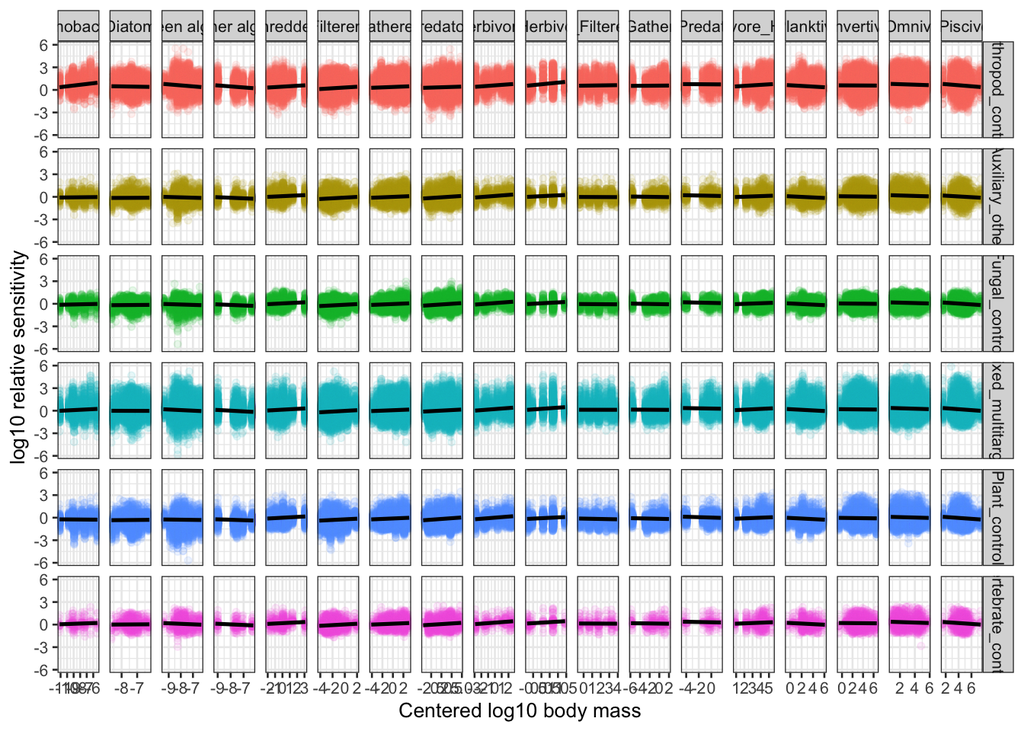

```r
plotdf <- spe_tax_phylo_BM_FFG_sensi_subCAS |> filter(duration == "24")
trophic_order <- c(
  "Cyanobacteria", "Diatom", "Green algae",  "Other algae",        # producers
  "I_Shredder_A", "I_Filterer_A", "I_Gatherer_A", "I_Predator_A", "I_Herbivore_A",
  "I_Herbivore", "I_Filterer", "I_Gatherer",  "I_Predator",  # grazers
  "V_Detritivore_Herbivore", "V_Planktivore", "V_Invertivore", "V_Omnivore", "V_Piscivore" )

plotdf <- plotdf %>%
  mutate(FG5 = factor(FG5, levels = trophic_order))

chem_group_quicklook <- ggplot(plotdf,
                               aes(x = log_mass_c, y = log_rel_sensi,
                                   col = chem_group, group = chem_group))+
  geom_point(alpha = 0.1) +
  geom_smooth(method = lm, se = FALSE, color="black") +
  facet_grid(chem_group ~ FG5, scale = "free_x") +
  theme_bw(base_size = 10) +
  labs(
    x = "Centered log10 body mass",
    y = "log10 relative sensitivity",
    col = "Chemical group") +
  theme(legend.position = "none")

chem_group_quicklook
```